# Machine Learning Algorithm Tuning with mlr3

# Intro

In this case we will be working with the **Ames Housing Dataset** from today’s kaggle challenge. We already used different `Learner`s on it and tried to optimize their hyperparameters. Today we will

- preprocess the data as an integrated step of the model fitting process
- tune the preprocessing parameters
- use multiple `Learners` in as an *ensemble* model

# Prerequisites

We expect you have installed all packages from day 1. If not, load the day 1 script and run the **Prerequisites** install chunk.

Additional packages needed:

```r
install.packages(c("mlr3filters", "visNetwork"))
remotes::install_github("mlr-org/mlr3pipelines")
remotes::install_github("mlr-org/mlr3learners")
```

Load the packages we are going to use:

```r
library("data.table")
library("magrittr")
library("mlr3")
library("mlr3learners")
library("ggplot2")
theme_set(theme_light())
library("mlr3tuning")
future::plan("multiprocess")
```

# Intro

In this tutorial we will take a look at composite machine learning algorithms that may incorporate data preprocessing or the combination of multiple `Learner`s (“ensemble methods”).

The package we use is **mlr3pipelines**, which enables us to chain “`PipeOp`” objects into data flow graphs. Load the package using

```r
library("mlr3pipelines")
```

We will start with a simple example and then go on to work on the Kaggle dataset we have seen the past two days. Get it at https://www.kaggle.com/c/ames-day3/data and save the datasets in the `data/` directory.

# Preprocessing

- Real world data often has properties that many Learners can not handle natively
  - missing values
  - categorical features
    - possibly with high cardinality
  - multicollinearity
    - an important instance of that: almost constant features
- Sometimes data needs to be transformed to make the available signal more compatible with the Learner and remove irrelevant noise (“feature extraction”)
  - remove irrelevant features (“feature extraction”)
  - add feature interactions

## Ames Housing Data

- As said before, you should have the ames data from https://www.kaggle.com/c/ames-day3/data saved in the `data/` directory.
- Note the `read.csv` call we use: both empty strings and ‘NA’ strings indicate missing values.
- Lets load the data and construct a `Task`

```r
train_set = read.csv("data/ames_housing_train_original.csv", na.string = c("", "NA"))
task = TaskRegr$new(id = "ames_housing", backend = train_set, target = "SalePrice")
```

- We instantiate a resampling instance for this task to be able to compare resampling performance.

```r
set.seed(8008135)
cv10_instance = rsmp("cv")$instantiate(task)
```

- Because the data is not very well behaved at all, we are going to make a smaller task in the beginning to try some things.

```r
small_task = task$clone()$select(c("Garage.Yr.Blt", "Lot.Frontage", "Bsmt.Exposure", "Yr.Sold"))
```

## Building an Imputation Pipeline

- We notice we have lots of “missing” data here. The `Task` object reports these with the `$missings()` function.

```r
small_task$missings()
```

```
#>     SalePrice Bsmt.Exposure Garage.Yr.Blt  Lot.Frontage       Yr.Sold
#>             0            56           109           325             0
```

- -> First we do *imputation*
- There are a few imputation `PipeOp`s

```r
mlr_pipeops$keys("impute")
```

```
#> [1] "imputehist"   "imputemean"   "imputemedian" "imputenewlvl" "imputesample"
```

- We will do median imputation for numeric features. What does it look like?
- Note we have to put the `Task` in a `list()` to train a `PipeOp`.

```r
imputed = po("imputemedian")$train(list(small_task))[[1]]
imputed$missings()
```

```
#>     SalePrice Bsmt.Exposure       Yr.Sold Garage.Yr.Blt  Lot.Frontage
#>             0            56             0             0             0
```

- It did not touch the factorial features!
- For factorial features, we will add a new level `.MISSING`
- We create a `Graph` from the two `PipeOp`s, they work one after the other.

```r
imputer = po("imputemedian") %>>% po("imputenewlvl")
imputer$plot(html = TRUE)
```

[interactive chart not shown]

```r
imputed = imputer$train(small_task)[[1]]
imputed$missings()
```

```
#>     SalePrice       Yr.Sold Garage.Yr.Blt  Lot.Frontage Bsmt.Exposure
#>             0             0             0             0             0
```

- Compare the levels of a random feature with the original task:

```r
small_task$levels("Bsmt.Exposure")
```

```
#> $Bsmt.Exposure
#> [1] "Av" "Gd" "Mn" "No"
```

```r
imputed$levels("Bsmt.Exposure")
```

```
#> $Bsmt.Exposure
#> [1] "Av"       "Gd"       "Mn"       "No"       ".MISSING"
```

- Let’s see how this works with a very simple learner, `regr.lm`.

```r
limo = lrn("regr.lm")
```

- Compare the original task: Gives an error

```r
resample(small_task, limo, cv10_instance)$aggregate(msr("regr.mae"))
```

```
#> Error in .subset2(public_bind_env, "initialize")(...): Learner 'regr.lm' on task 'ames_housing' failed to predict: Assertion on 'response' failed: Contains missing values (element 6).
```

- With the imputer, should work

```r
resample(small_task, imputer %>>% limo, cv10_instance)$aggregate(msr("regr.mae"))
```

```
#> regr.mae
#> 42884.19
```

- The `Learner` would not know know which data was imputed
- We add “missing indicator” columns
- `po("missind")` is used for this, *but* it removes all original columns!

```r
po("missind")$train(list(small_task))[[1]]
```

```
#> <TaskRegr:ames_housing> (1953 x 4)
#> * Target: SalePrice
#> * Properties: -
#> * Features (3):
#>   - fct (3): missing_Bsmt.Exposure, missing_Garage.Yr.Blt, missing_Lot.Frontage
```

- We need to calculate in parallel!

```
             ----------
[INPUT] -+-->| impute |--------,
         |   ----------        |
         |                     V
         |   -----------   -----------
         `-->| missind |-->| Feature |--> [OUTPUT]
             -----------   |  Union  |
                           -----------
```

- For this we need the “upper” lane: we have it already, `imputer`
- The lower lane is just `po("missind")`
- We combine everything in `po("featureunion")`

```r
impandmiss = gunion(list(imputer, po("missind"))) %>>% po("featureunion")

impandmiss$plot(html = TRUE)
```

[interactive chart not shown]

```r
impandmiss$train(small_task)[[1]]
```

```
#> <TaskRegr:ames_housing> (1953 x 8)
#> * Target: SalePrice
#> * Properties: -
#> * Features (7):
#>   - fct (4): Bsmt.Exposure, missing_Bsmt.Exposure, missing_Garage.Yr.Blt, missing_Lot.Frontage
#>   - int (3): Garage.Yr.Blt, Lot.Frontage, Yr.Sold
```

- When training this the result contains both the imputed features, and also the missing indicator columns
- There are *too many* missing indicator columns: `"Bsmt.Exposure"` is a factorial column, so the `.MISSING` level already shows there is missing data–`"missing_Bsmt.Exposure"` is superfluous
- We therefore prepend `missind` with the `"select"` `PipeOp` that filters out all the non-integer columns.

```r
impandmiss = gunion(list(imputer, po("select", selector = selector_type("integer")) %>>% po("missind"))) %>>% po("featureunion")

impandmiss$plot(html = TRUE)
```

[interactive chart not shown]

```r
impandmiss$train(small_task)[[1]]
```

```
#> <TaskRegr:ames_housing> (1953 x 7)
#> * Target: SalePrice
#> * Properties: -
#> * Features (6):
#>   - fct (3): Bsmt.Exposure, missing_Garage.Yr.Blt, missing_Lot.Frontage
#>   - int (3): Garage.Yr.Blt, Lot.Frontage, Yr.Sold
```

```r
impandmiss$train(small_task)[[1]]$head(8)
```

```
#>    SalePrice Yr.Sold Garage.Yr.Blt Lot.Frontage Bsmt.Exposure missing_Garage.Yr.Blt missing_Lot.Frontage
#> 1:    215000    2010          1960          141            Gd               present              present
#> 2:    172000    2010          1958           81            No               present              present
#> 3:    244000    2010          1968           93            No               present              present
#> 4:    189900    2010          1997           74            No               present              present
#> 5:    195500    2010          1998           78            No               present              present
#> 6:    213500    2010          2001           41            Mn               present              present
#> 7:    175900    2010          1993           75            No               present              present
#> 8:    185000    2010          1992           68            No               present              missing
```

```r
resample(small_task, impandmiss %>>% limo, cv10_instance)$aggregate(msr("regr.mae"))
```

```
#> regr.mae
#>  41223.2
```

- This gives us a smaller MAE, possibly the learner is making use of the information that a value was actually imputed.

## Making Models more robust

- If we try this pipelne with the full `Task`, we run into trouble: Our model doesn’t know how to handle new factor levels during prediction.

```r
resample(task, impandmiss %>>% limo, cv10_instance)
```

```
#> Error in model.frame.default(Terms, newdata, na.action = na.action, xlev = object$xlevels): Learner 'imputemedian.select.imputenewlvl.missind.featureunion.regr.lm' on task 'ames_housing' failed to predict: Learner 'regr.lm' on task 'ames_housing' failed to predict: factor Condition.2 has new leve…
```

- Problem: Test set contains levels that were not seen during training, which the `Learner` can not handle
- We use another `PipeOp`, `"fixfactors"`, that makes sure no new levels are introduced:
  - It remembers during training what factor levels were seen
  - It converts unseen factor levels during prediction to `NA` values.
- These `NA` values we have to impute *again*, but not with the `.MISSING` imputer—it could add new levels again!
- Instead we use the `"imputesample"` imputer: it samples randomly from the training set.
- We also add the `"removeconstants"` pipeop, because it is possible that a training split only contains a single level, which could break learners.

```r
robustify = po("fixfactors") %>>% po("imputesample") %>>% po("removeconstants")
robustimp = impandmiss %>>% robustify
```

```r
resample(task, robustimp %>>% limo, cv10_instance)$aggregate(msr("regr.mae"))
```

```
#> regr.mae
#> 16510.53
```

- Taking into account more features sure pays off!
- But we get a warning about rank deficient matrix, we should try a model that can handle large numbers of features

```r
resample(task, robustimp %>>% lrn("regr.ranger"), cv10_instance)$aggregate(msr("regr.mae"))
```

```
#> regr.mae
#> 15504.24
```

## Collapsing Factors and Tuning

- We can use the `"collapsefactors"` `PipeOp` to remove very infrequent factors.
- How many should we collapse? Let’s find out by tuning.

```r
collapsinglrn = GraphLearner$new(robustimp %>>% po("collapsefactors") %>>% lrn("regr.lm"))
```

- We look at the `ParamSet` to see which parameter we can tune. There are a lot! Each parameter is named after the `PipeOp` it belongs to.

```r
collapsinglrn$param_set
```

```
#> ParamSet:
#>                                               id    class lower upper                 levels     default
#>  1:                  imputemedian.affect_columns ParamUty    NA    NA                        <NoDefault>
#>  2:                  imputenewlvl.affect_columns ParamUty    NA    NA                        <NoDefault>
#>  3:                              select.selector ParamUty    NA    NA                        <NoDefault>
#>  4:                        select.affect_columns ParamUty    NA    NA                        <NoDefault>
#>  5:                                missind.which ParamFct    NA    NA      missing_train,all <NoDefault>
#>  6:                                 missind.type ParamFct    NA    NA numeric,factor,logical <NoDefault>
#>  7:                       missind.affect_columns ParamUty    NA    NA                        <NoDefault>
#>  8:                        fixfactors.droplevels ParamLgl    NA    NA             TRUE,FALSE <NoDefault>
#>  9:                    fixfactors.affect_columns ParamUty    NA    NA                        <NoDefault>
#> 10:                  imputesample.affect_columns ParamUty    NA    NA                        <NoDefault>
#> 11:                        removeconstants.ratio ParamDbl     0     1                        <NoDefault>
#> 12:                      removeconstants.rel_tol ParamDbl     0   Inf                        <NoDefault>
#> 13:                      removeconstants.abs_tol ParamDbl     0   Inf                        <NoDefault>
```

[output cut: 24 more lines]

- We optimize the `collapsefactors.target_level_count` parameter.

```r
library("paradox")
searchspace = ParamSet$new(list(
  ParamDbl$new("log_collapsefactors.target_level_count", lower = log(2), upper = log(100))
))
searchspace$trafo = function(x, param_set) {
  list(collapsefactors.target_level_count = round(exp(x$log_collapsefactors.target_level_count)))
}
```

- Because this is only one parameter, we will use grid search. For higher dimensions, random search is more appropriate.

```r
inst = TuningInstance$new(
  task, collapsinglrn, cv10_instance, msr("regr.mae"),
  searchspace, term("none")
)
tuner = tnr("grid_search", resolution = 10)
```

```r
tuner$tune(inst)
```

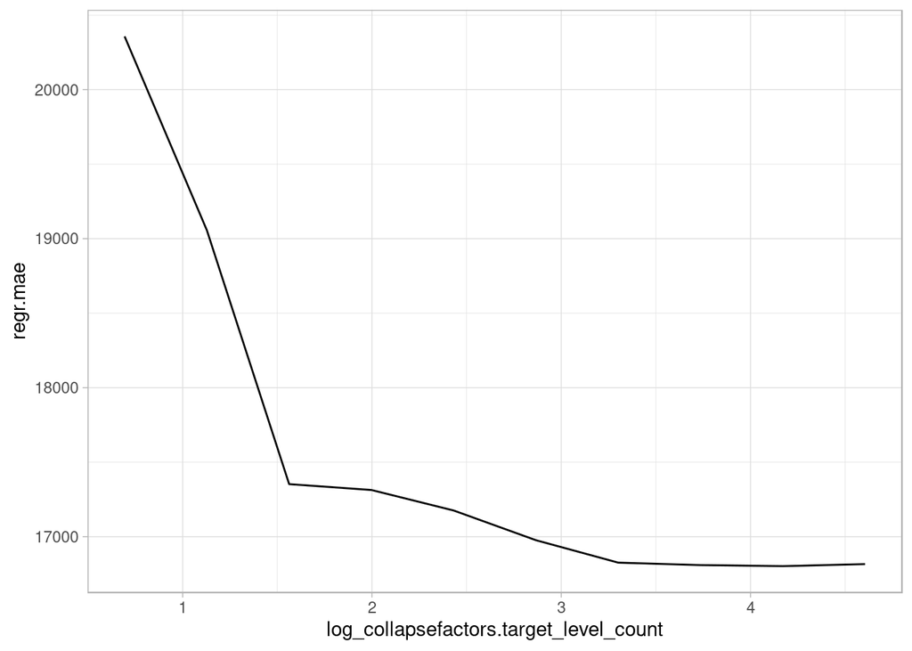

```r
arx = inst$archive("tune_x")
ggplot(arx, aes(x = log_collapsefactors.target_level_count, y = regr.mae)) + geom_line()
```

- Ultimately this does not appear to be very successful

```r
inst$result
```

```
#> $tune_x
#> $tune_x$log_collapsefactors.target_level_count
#> [1] 4.170501
#>
#>
#> $params
#> $params$select.selector
#> selector_type("integer")
#>
#> $params$missind.which
#> [1] "missing_train"
#>
#> $params$missind.type
#> [1] "factor"
#>
#> $params$fixfactors.droplevels
#> [1] TRUE
#>
#> $params$removeconstants.ratio
#> [1] 0
#>
#> $params$removeconstants.rel_tol
#> [1] 1e-08
#>
#> $params$removeconstants.abs_tol
#> [1] 1e-08
#>
#> $params$removeconstants.na_ignore
#> [1] TRUE
#>
#> $params$collapsefactors.no_collapse_above_prevalence
#> [1] 1
#>
#> $params$collapsefactors.target_level_count
#> [1] 65
#>
#>
#> $perf
#> regr.mae
#> 16802.55
```

# Other Preprocessing Ideas

## Feature Selection

- A common use case for preprocessing is feature filtering
- `mlr3pipelines` makes use of the `mlr3filters` package

```r
library("mlr3filters")
mlr_filters
```

```
#> <DictionaryFilter> with 16 stored values
#> Keys: anova, auc, carscore, cmim, correlation, disr, importance, information_gain, jmi, jmim,
#>   kruskal_test, mim, mrmr, njmim, performance, variance
```

- We try the `correlation` filter. For clarity we will also drop all non-integer features

```r
fltgraph = robustimp %>>% po("select", id = "selector2", selector = selector_type("integer")) %>>%
  po("filter", flt("correlation"), filter.nfeat = 10)

fltgraph$plot(html = TRUE)
```

[interactive chart not shown]

```r
fltgraph$train(task)[[1]]$data()
```

```
#>       SalePrice Full.Bath Garage.Area Garage.Cars Gr.Liv.Area Overall.Qual X1st.Flr.SF Year.Built
#>    1:    215000         1         528           2        1656            6        1656       1960
#>    2:    172000         1         312           1        1329            6        1329       1958
#>    3:    244000         2         522           2        2110            7        2110       1968
#>    4:    189900         2         482           2        1629            5         928       1997
#>    5:    195500         2         470           2        1604            6         926       1998
#>   ---
#> 1949:    142500         1         588           2        1003            6        1003       1984
#> 1950:    131000         1         484           2         902            5         902       1983
#> 1951:    132000         1           0           0         970            5         970       1992
#> 1952:    170000         1         418           2        1389            5        1389       1974
#> 1953:    188000         2         650           3        2000            7         996       1993
#>       Year.Remod.Add Garage.Yr.Blt Total.Bsmt.SF
#>    1:           1960          1960          1080
#>    2:           1958          1958          1329
#>    3:           1968          1968          2110
#>    4:           1998          1997           928
#>    5:           1998          1998           926
#>   ---
#> 1949:           1984          1984          1003
#> 1950:           1983          1983           864
#> 1951:           1992          1980           912
#> 1952:           1975          1975          1389
#> 1953:           1994          1993           996
```

- The performance is not stellar, but having few features is helpful when trying to interpret the model

```r
rr = resample(task, fltgraph %>>% limo, cv10_instance, store_model = TRUE)
rr$aggregate(msr("regr.mae"))
```

```
#> regr.mae
#>  23667.9
```

```r
summary(rr$learners[[1]]$model$regr.lm$model)
```

```
#>
#> Call:
#> stats::lm(formula = task$formula(), data = task$data())
#>
#> Residuals:
#>     Min      1Q  Median      3Q     Max
#> -465441  -19009   -2445   15270  302669
#>
#> Coefficients:
#>                  Estimate Std. Error t value Pr(>|t|)
#> (Intercept)    -1.308e+06  1.196e+05 -10.941  < 2e-16 ***
#> Full.Bath      -9.748e+03  2.442e+03  -3.991 6.85e-05 ***
#> Garage.Area     1.655e+01  9.652e+00   1.715 0.086495 .
#> Garage.Cars     1.050e+04  2.760e+03   3.804 0.000147 ***
#> Gr.Liv.Area     4.820e+01  2.809e+00  17.160  < 2e-16 ***
#> Overall.Qual    2.004e+04  1.022e+03  19.603  < 2e-16 ***
#> X1st.Flr.SF     1.823e+01  4.352e+00   4.188 2.95e-05 ***
#> Year.Built      2.637e+02  5.477e+01   4.815 1.60e-06 ***
#> Year.Remod.Add  2.967e+02  5.942e+01   4.992 6.56e-07 ***
#> Garage.Yr.Blt   7.022e+01  6.325e+01   1.110 0.267057
#> Total.Bsmt.SF   1.384e+01  3.777e+00   3.664 0.000256 ***
#> ---
#> Signif. codes:  0 '***' 0.001 '**' 0.01 '*' 0.05 '.' 0.1 ' ' 1
#>
#> Residual standard error: 37270 on 1746 degrees of freedom
#> Multiple R-squared:  0.7785, Adjusted R-squared:  0.7773
#> F-statistic: 613.8 on 10 and 1746 DF,  p-value: < 2.2e-16
```

## PCA

A popular preprocessing method for feature extraction is principal component analysis - We use the `"pca"` `PipeOp` and take the first 20 principal components - Again just from the numerical features

```r
pcagraph = robustimp %>>% po("select", id = "selector2", selector = selector_type("integer")) %>>%
  po("pca", rank. = 20)
```

```r
rr = resample(task, pcagraph %>>% limo, cv10_instance, store_model = TRUE)
rr$aggregate(msr("regr.mae"))
```

```
#> regr.mae
#> 24988.32
```

```r
summary(rr$learners[[1]]$model$regr.lm$model)
```

```
#>
#> Call:
#> stats::lm(formula = task$formula(), data = task$data())
#>
#> Residuals:
#>     Min      1Q  Median      3Q     Max
#> -481046  -18817   -3693   14205  255824
#>
#> Coefficients:
#>               Estimate Std. Error t value Pr(>|t|)
#> (Intercept)  1.797e+05  9.379e+02 191.589  < 2e-16 ***
#> PC1         -1.056e-04  4.968e-06 -21.258  < 2e-16 ***
#> PC2          2.385e+00  1.133e-01  21.043  < 2e-16 ***
#> PC3          4.909e+01  1.277e+00  38.432  < 2e-16 ***
#> PC4          6.566e+01  1.438e+00  45.670  < 2e-16 ***
#> PC5          1.051e+01  1.613e+00   6.518 9.33e-11 ***
#> PC6          1.943e+01  1.802e+00  10.784  < 2e-16 ***
#> PC7         -2.352e+00  4.241e+00  -0.555 0.579203
#> PC8         -2.024e+01  5.382e+00  -3.761 0.000175 ***
#> PC9          8.944e+01  5.468e+00  16.355  < 2e-16 ***
#> PC10         6.345e+00  6.157e+00   1.030 0.302924
#> PC11         3.788e+01  8.048e+00   4.706 2.73e-06 ***
#> PC12        -8.038e+01  1.365e+01  -5.890 4.64e-09 ***
#> PC13         5.868e+00  1.535e+01   0.382 0.702298
#> PC14        -1.468e+00  1.625e+01  -0.090 0.928023
#> PC15         2.276e+01  1.696e+01   1.342 0.179692
#> PC16        -3.473e+01  2.377e+01  -1.461 0.144125
#> PC17        -5.320e+02  3.238e+01 -16.429  < 2e-16 ***
#> PC18         1.009e+02  3.541e+01   2.849 0.004440 **
#> PC19        -3.743e+02  3.566e+01 -10.497  < 2e-16 ***
#> PC20         4.417e+01  5.487e+01   0.805 0.421003
#> ---
#> Signif. codes:  0 '***' 0.001 '**' 0.01 '*' 0.05 '.' 0.1 ' ' 1
#>
#> Residual standard error: 39310 on 1736 degrees of freedom
#> Multiple R-squared:  0.755,  Adjusted R-squared:  0.7522
#> F-statistic: 267.5 on 20 and 1736 DF,  p-value: < 2.2e-16
```

# Multiple Learners

## Mean Aggregation

- Use multiple learners, aggregate their mean prediction
- May give better results if individual learners predict well on average with high variance

```r
meangraph = robustimp %>>% list(lrn("regr.lm"), lrn("regr.ranger"), lrn("regr.kknn")) %>>% po("regravg")

meangraph$plot(html = TRUE)
```

[interactive chart not shown]

```r
rr = resample(task, meangraph, cv10_instance, store_model = TRUE)
rr$aggregate(msr("regr.mae"))
```

```
#> regr.mae
#> 15029.43
```

## Stacking

- Instead of just mean-aggregating predictions, we build a model on the predictions of learners
- This needs the `"learner_cv"` PipeOp, because predictions need to be available during training already
  - the `"learner_cv"` PipeOp performs crossvalidation during the training phase and emits the cross validated predictions.

```r
stackgraph = robustimp %>>%
  list(po("learner_cv", id = "stack_lm", robustify %>>% lrn("regr.lm")),
    po("learner_cv", lrn("regr.ranger")),
    po("learner_cv", lrn("regr.kknn"))) %>>%
  po("featureunion", id = "fu2") %>>% lrn("regr.lm")

stackgraph$plot(html = TRUE)
```

[interactive chart not shown]

```r
rr = resample(task, stackgraph, cv10_instance, store_model = TRUE)
rr$aggregate(msr("regr.mae"))
```

```
#> regr.mae
#> 14914.52
```

# Your Ideas!

- Try different methods for preprocessing and training
- Some hints:
  - It is not allowed to have two `PipeOp`s with the same `ID` in a `Graph`. Initialize a `PipeOp` with `po("...", id = "xyz")` to change its ID on construction
  - Don’t build too large `Graph`s involving complicated optimizations, like too many `"learner_cv"`–they need a long time to train
  - Use the `affect_columns` parameter if you want a `PipeOp` to only operate on part of the data. Use `po("select")` if you want to remove certain columns (possibly only along a single branch of multiple parallel branches). Both take `selector_XXX()` arguments, e.g. `selector_type("integer")`
  - You may get the best performance if you actually inspect the features and see what kind of transformations work best for them.
  - See what `PipeOp`s are available by inspecting `mlr_pipeops$keys()`, and get help about them using `?mlr_pipeops_XXX`.

# Demo Submission

- How we constructed our stacking model

```r
imputer = po("imputemedian") %>>% po("imputenewlvl")

impandmiss = gunion(list(imputer, po("select", selector = selector_type("integer")) %>>%
  po("missind"))) %>>%
  po("featureunion")

robustify = po("fixfactors") %>>% po("imputesample") %>>% po("removeconstants")
robustimp = impandmiss %>>% robustify

stackgraph = robustimp %>>%
  list(po("learner_cv", id = "stack_lm", robustify %>>% lrn("regr.lm")),
    po("learner_cv", lrn("regr.ranger")),
    po("learner_cv", lrn("regr.kknn"))) %>>%
  po("featureunion", id = "fu2") %>>% lrn("regr.lm")

resample(task, stackgraph, cv10_instance, store_model = TRUE)$aggregate(msr("regr.mae"))
```

```
#> regr.mae
#> 15059.83
```

- Training it on the whole dataset and creating a prediction submission

```r
test_set = read.csv("data/ames_housing_test_original.csv")

final_learner = GraphLearner$new(stackgraph)$train(task)

pred = final_learner$predict_newdata(task, test_set)
pred = as.data.table(pred)
pred$truth = NULL
write.csv(pred, "data/ames_housing_submission_day3.csv", row.names = FALSE)
```